# HW 03

Author

Kristy Feinberg

## Set Up

```r
library(tidyverse)
```

```r
mario_kart <- read_csv("https://raw.githubusercontent.com/vaiseys/dav-course/main/Data/world_records.csv")
glimpse(mario_kart)
```

```
Rows: 2,334
Columns: 9
$ track           <chr> "Luigi Raceway", "Luigi Raceway", "Luigi Raceway", "Lu…
$ type            <chr> "Three Lap", "Three Lap", "Three Lap", "Three Lap", "T…
$ shortcut        <chr> "No", "No", "No", "No", "No", "No", "No", "No", "No", …
$ player          <chr> "Salam", "Booth", "Salam", "Salam", "Gregg G", "Rocky …
$ system_played   <chr> "NTSC", "NTSC", "NTSC", "NTSC", "NTSC", "NTSC", "NTSC"…
$ date            <date> 1997-02-15, 1997-02-16, 1997-02-16, 1997-02-28, 1997-…
$ time_period     <chr> "2M 12.99S", "2M 9.99S", "2M 8.99S", "2M 6.99S", "2M 4…
$ time            <dbl> 132.99, 129.99, 128.99, 126.99, 124.51, 122.89, 122.87…
$ record_duration <dbl> 1, 0, 12, 7, 54, 0, 0, 27, 0, 64, 3, 0, 90, 132, 1, 74…
```

## Question 1

```r
three_laps <- mario_kart %>% filter(type == "Three Lap")
```

**How would you create a dataset that does not contain any times recorded on that infamous track?**

The two ways to remove data are by using filter() or select(). Because the Tracks are column data and we want to remove Rainbow Road, we will filter for that track. We will use a “!=” to indicate does not equal when filtering for “Rainbow Road”.

```r
three_laps_no_rainbow <- three_laps %>% filter(track != "Rainbow Road")
```

Now, save a dataset that only contains the records achieved at Rainbow Road.

```r
Rainbow_Road <- three_laps %>% filter(track == "Rainbow Road")
```

## Question 2

Use `summarize()` to get the average time and standard deviation of records set at Rainbow Road.

```r
Rainbow_Road |>
  summarize(avg_time = mean(time),
            sd_time = sd(time))
```

```
# A tibble: 1 × 2
  avg_time sd_time
     <dbl>   <dbl>
1     276.    91.8
```

Now, do the same for the dataset that contains all other tracks.

```r
three_laps_no_rainbow  |>
  summarize(avg_time = mean(time),
            sd_time = sd(time))
```

```
# A tibble: 1 × 2
  avg_time sd_time
     <dbl>   <dbl>
1     114.    53.0
```

**Notice any differences?**

Rainbow Road has a much longer average time and standard deviation than the average all the other tracks.

## Question 3

```r
three_laps |>
  group_by(track) |>
  summarize(records = n()) |>
  arrange(desc(records))
```

```
# A tibble: 16 × 2
   track                 records
   <chr>                   <int>
 1 Toad's Turnpike           124
 2 Rainbow Road               99
 3 Frappe Snowland            92
 4 D.K.'s Jungle Parkway      86
 5 Choco Mountain             84
 6 Mario Raceway              82
 7 Luigi Raceway              81
 8 Royal Raceway              77
 9 Yoshi Valley               74
10 Kalimari Desert            73
11 Sherbet Land               73
12 Wario Stadium              71
13 Koopa Troopa Beach         56
14 Banshee Boardwalk          55
15 Moo Moo Farm               44
16 Bowser's Castle            40
```

**What’s the track that has had the most records established in it?**

Toad’s Turnpike

## Question 4

We want to know if there are drivers who have multiple records at each track, and how many records they have. This will involve grouping by both driver and track.

```r
three_laps |>
  group_by(player,track) |>
  summarize(records = n()) |>
  arrange(desc(records))
```

```
# A tibble: 306 × 3
# Groups:   player [60]
   player   track                 records
   <chr>    <chr>                   <int>
 1 Penev    Choco Mountain             26
 2 Lacey    D.K.'s Jungle Parkway      24
 3 abney317 Rainbow Road               21
 4 MR       Toad's Turnpike            20
 5 MR       Frappe Snowland            18
 6 Penev    Toad's Turnpike            18
 7 MR       Sherbet Land               16
 8 abney317 Kalimari Desert            16
 9 MR       Banshee Boardwalk          15
10 Penev    Rainbow Road               15
# ℹ 296 more rows
```

**Who is the player that has recorded the most records at any one track and what track was it?**

Penev recorded the most records at track Choco Mountain

## Question 5

Tell me what the average time for each track is using `group_by` and `summarize`.

```r
three_laps |>
  group_by(track) |>
  summarize(avg_time = mean(time)) |>
  arrange(desc(avg_time))
```

```
# A tibble: 16 × 2
   track                 avg_time
   <chr>                    <dbl>
 1 Rainbow Road             276.
 2 Wario Stadium            214.
 3 Royal Raceway            158.
 4 Bowser's Castle          134.
 5 Kalimari Desert          126.
 6 Banshee Boardwalk        126.
 7 Toad's Turnpike          122.
 8 Sherbet Land             116.
 9 Luigi Raceway            104.
10 D.K.'s Jungle Parkway    101.
11 Koopa Troopa Beach        96.6
12 Choco Mountain            95.2
13 Moo Moo Farm              88.4
14 Yoshi Valley              82.7
15 Mario Raceway             79.1
16 Frappe Snowland           77.1
```

**What track has the highest average time?**

Rainbow Road has the highest average time of 275.63

For example we can pick the lowest time for each player like this:

```r
three_laps %>%
  group_by(player) %>%
  arrange(time) %>%
  slice(1) %>%
  head()
```

```
# A tibble: 6 × 9
# Groups:   player [6]
  track         type  shortcut player system_played date       time_period  time
  <chr>         <chr> <chr>    <chr>  <chr>         <date>     <chr>       <dbl>
1 Choco Mounta… Thre… Yes      ABE    NTSC          1997-06-01 1M 39.79S    99.8
2 Yoshi Valley  Thre… Yes      Alex G PAL           2010-11-27 33.39S       33.4
3 Frappe Snowl… Thre… Yes      Allen… NTSC          1997-10-31 28.22S       28.2
4 Wario Stadium Thre… Yes      Ben M  PAL           2002-08-22 15.48S       15.5
5 Frappe Snowl… Thre… Yes      Booth  NTSC          1998-09-18 27.11S       27.1
6 Mario Raceway Thre… No       Dan    PAL           2020-08-13 1M 27.51S    87.5
# ℹ 1 more variable: record_duration <dbl>
```

Show me the best time recorded on each track

```r
three_laps %>%
  group_by(track) %>%
  arrange(time) %>%
  slice(1) %>%
  head() %>%
  select(time) %>%
  arrange(time)
```

```
# A tibble: 6 × 2
# Groups:   track [6]
  track                  time
  <chr>                 <dbl>
1 Choco Mountain         17.3
2 D.K.'s Jungle Parkway  21.4
3 Frappe Snowland        23.6
4 Kalimari Desert       122.
5 Banshee Boardwalk     124.
6 Bowser's Castle       132
```

## Question 6

Create a new variable that is a `1` if `record_duration` is higher than 100 or 0 otherwise.

```r
long_records <- three_laps |>
  mutate(over_100 = if_else(record_duration > 100, 1L, 0L))
```

Now, grouping by player, tell me the total amount of long duration records each player holds.

```r
num_long_records <- long_records %>% filter(over_100 == 1)
```

```r
num_long_records %>%
  group_by(player) %>%
  summarize(num_long_records = n()) %>%
  arrange(desc(num_long_records))
```

```
# A tibble: 42 × 2
   player   num_long_records
   <chr>               <int>
 1 MR                     81
 2 MJ                     50
 3 Penev                  27
 4 VAJ                    26
 5 abney317               26
 6 Zwartjes               24
 7 Lacey                  23
 8 Dan                    21
 9 Karlo                  18
10 Booth                  17
# ℹ 32 more rows
```

**What player has the most long duration records?**

Player MR

## Question 7

```r
drivers <- read_csv("https://raw.githubusercontent.com/vaiseys/dav-course/main/Data/drivers.csv")
```

```r
mod_drivers <- drivers %>%
  select(player, nation) %>%
  group_by(player) %>%
  slice_head(n=1)
```

```r
joined_drivers <- left_join(three_laps,
                            mod_drivers)
```

```r
nation_record <-joined_drivers |>
  group_by(nation) |>
  summarize(nation_count = n())
```

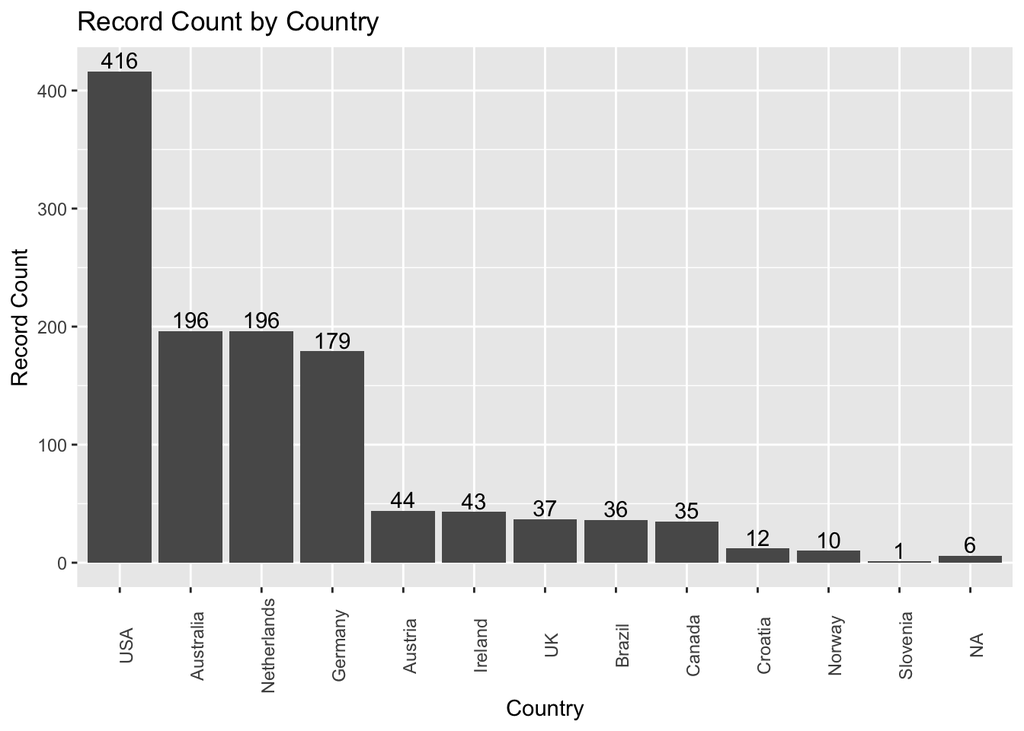

```r
nation_record <- joined_drivers |>
  group_by(nation) |>
  summarize(count_records = n())

nation_sorted <- nation_record |>
  arrange(desc(count_records))

nation_sorted |>
  ggplot(aes(x = reorder(nation, -count_records), y = count_records)) +
  geom_bar(stat = "identity") +
  geom_text(aes(label = count_records), vjust = -.2)+
  theme(axis.text.x = element_text(angle = 90))+ #looked this up online for aesthetic purposes
  labs(x = "Country", y = "Record Count", title = "Record Count by Country")
```